# Datathon 2

28 November 2017

## Introduction

### **Can electoral engineering prevent conflicts?**

- Social relevance: Peace processes in (ethnically) divided societies
- Research gap: testing theoretical argument, mostly case studies

Research Design:

- Database of Political Institutions 2015 (World Bank) + UCDP/PRIO
- PCA, clustering, logistic regression vs Support vector

## Previous Work & theoretical framework

**"The key to regulating conflict is to change the conditions that encourage it, via alternative institutional designs" (Reilly 2001)**

- Power-sharing through electoral rules lowers risk of war in diverse societies (Schneider/Wiesehomeier 2008)
- Case Study Iraq: PR instead of majoritarian systems (Dawisha/Diamond 2006)
- Minority representation, incentives to cooperate, centripetalism

**H: With increased diversity of the political system, the likelihood of conflicts decreases.**

## Unsupervised data exploration

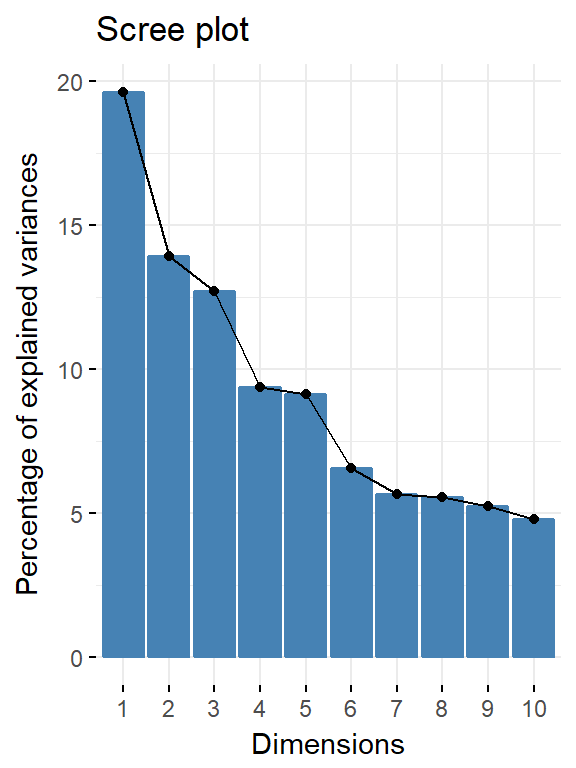

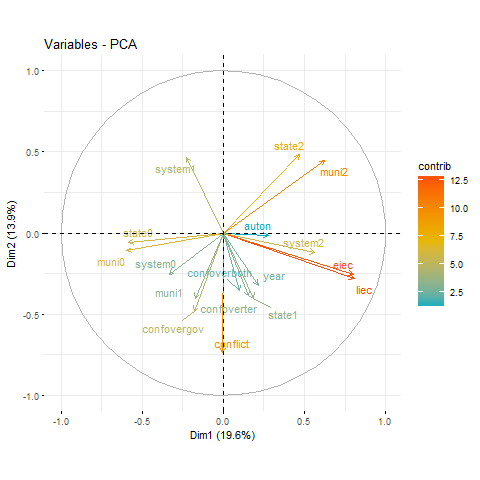

## Unsupervised: H-clust on first 6 PC

H-clust 6 PC - complete

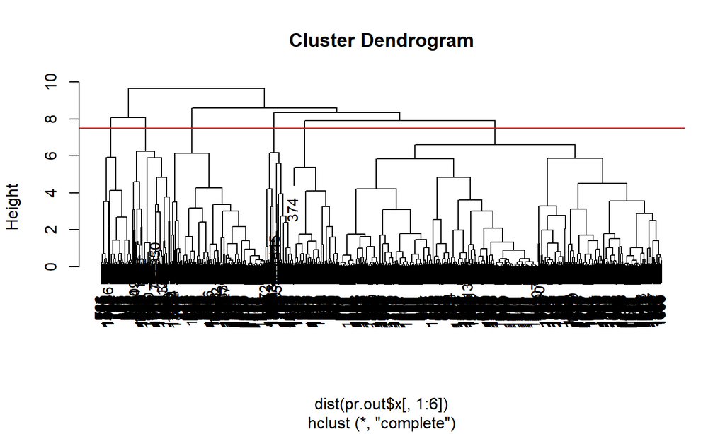

H-clust 6 PC - correlation

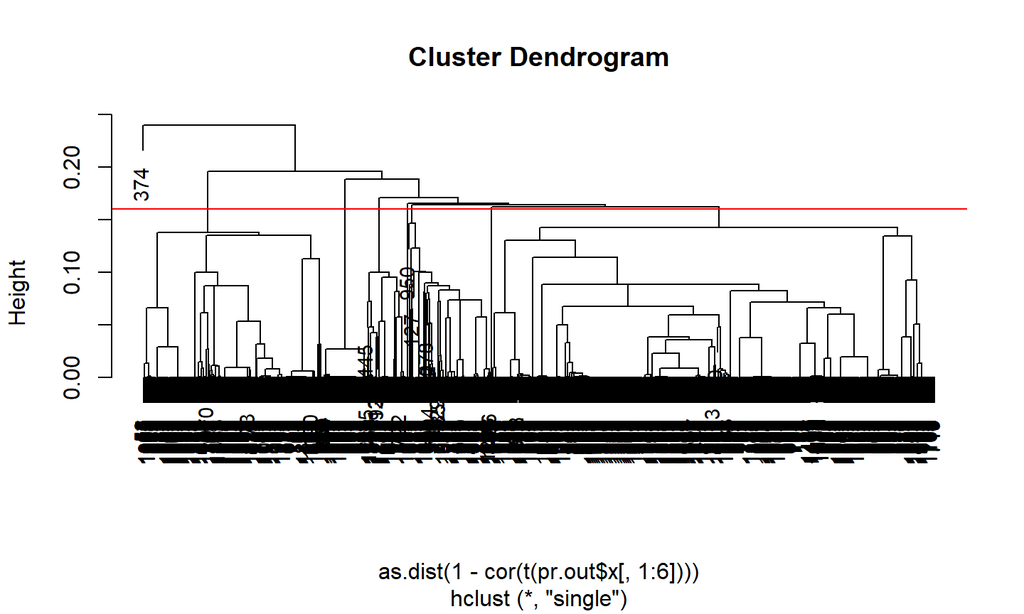

**Complete vs. Correlation**

- 6 complete-clusters vs. 1st correlation-cluster
- what binds 1st correlation-cluster?

```
##
##       1   2   3   4   5   6
##   1 263   0   0   0   0   0
##   2 102   0   0   0   0   0
##   3 457 340   0  83   0   4
##   4  86   0   0   0   0   0
##   5   0   0  77   0   0   0
##   6 113  11   0   0   1   0
```